Load required packages

```r
#install.packages("dplyr")
library(dplyr)
```

**dplyr**

We can usually manipulate data frames using the dplyr package more easily than using base R. Import the data and subset to retain the date,country,type and cases column using the dplyr package (hint:use the `select` command)

```r
covid=read.csv("coronavirus.csv")
covid = select(covid, c("date","country","type","cases"))
head(covid)
```

```
##         date     country      type cases
## 1 2020-01-22 Afghanistan confirmed     0
## 2 2020-01-23 Afghanistan confirmed     0
## 3 2020-01-24 Afghanistan confirmed     0
## 4 2020-01-25 Afghanistan confirmed     0
## 5 2020-01-26 Afghanistan confirmed     0
## 6 2020-01-27 Afghanistan confirmed     0
```

## Histogram

We have data where we can see how many deaths have taken place every day for several months in several countries. Let’s look at the distribution of daily deaths around the world.

We first want to focus on **death** only. Filter the dataset to retain rows where the “type” column contains the text “death” and store in a new variable called “deaths” (hint: retain rows where covid$type==“death”)

```r
deaths = filter(covid,
             type == "death")
```

Now we simply use the `hist()` function to create a histogram of the cases in deaths.

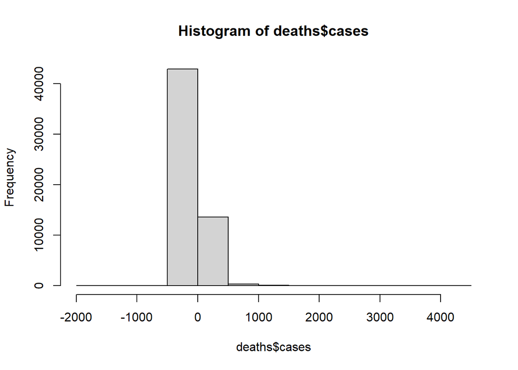

```r
hist(deaths$cases)
```

When the values are quite variable, it is better to visualize them in *log* scale. Create a histogram of log10 values of cases.

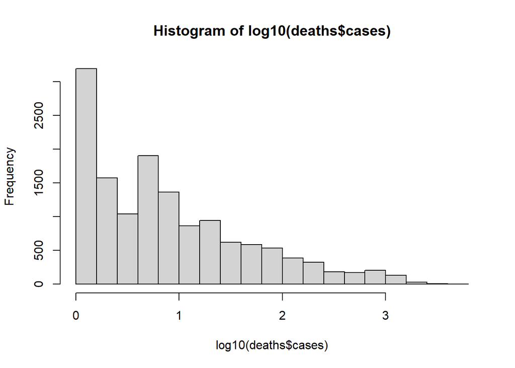

```r
hist(log10(deaths$cases))
```

## Barplots

Let’s see how the total number of **confirmed** cases changed across the different months. Based on the data we have, we can do this daily, however it maybe easier to visualize this monthly. To help us convert the days to months, we will use the `substr()` function to trim the date and add the new date as a new column to our covid dataframe.

See the results of the command `substr(covid$date, 1, 7)`. The `1` specifes where to start and `7` specifies where to end. How would you add this new trimmed date to the dataframe as a new column, named `newdate` to the original covid dataframe?

```r
covid = mutate(covid, newdate=substr(date,1,7))
```

Now let’s create a new object, call is **usa_monthly_average** using `group_by()` and `summarise()` functions to get the sum of all cases for each `newdate`. Start with the original covid dataset and filter **USA** from the **country** column and **confirmed** from **type** column.

```r
usa_monthly_average = covid %>%
  filter(country=="US") %>%
  filter(type=="confirmed") %>%
  group_by(newdate) %>%
  summarise(totalcases=sum(cases),.groups="drop")
```

Finally let’s create a barplot of this data. To help make the plot look nicer, use the `names` option to specify the labels names and also `las=2` which makes the label names perpendicular to the axis. Check out `?par` for a list of many other graphic parameters.

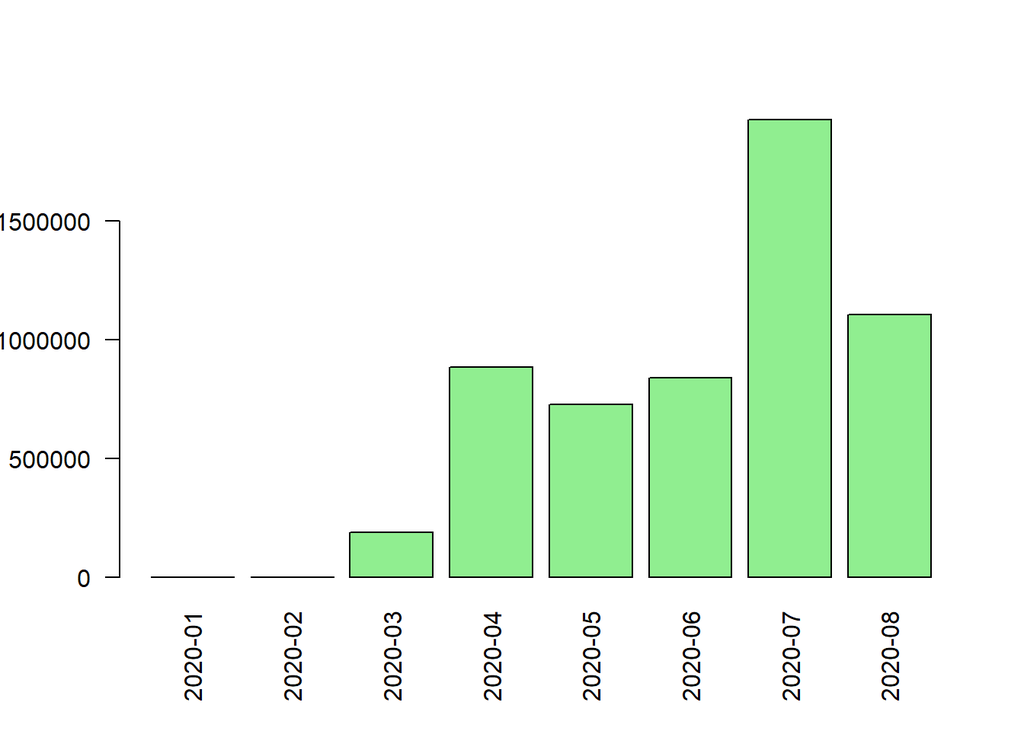

```r
barplot(usa_monthly_average$totalcases,
        names = usa_monthly_average$newdate,
        horiz = F, las=2, col="lightgreen")
```

Create the same barplot for Italy using a new object called **italy_monthly_average**.

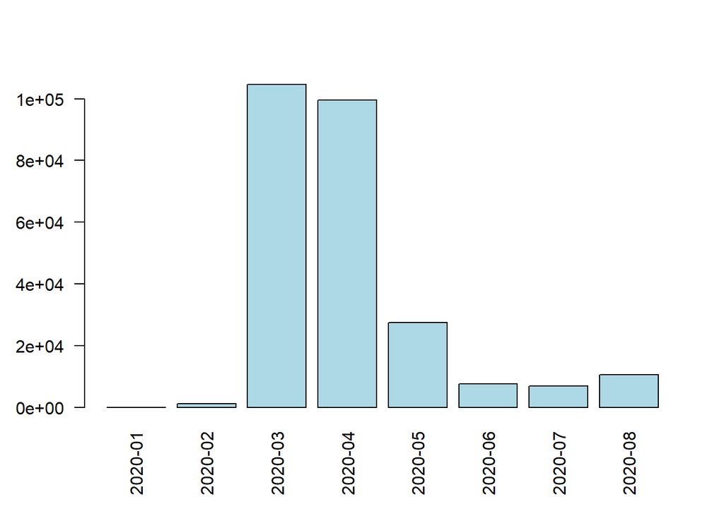

```r
italy_monthly_average = covid %>%
  filter(country == "Italy") %>%
  filter(type=="confirmed") %>%
  group_by(newdate) %>%
  summarise(totalcases=sum(cases), .groups="drop")

barplot(italy_monthly_average$totalcases,
        names = italy_monthly_average$newdate,
        horiz = F, las=2, col="lightblue")
```

Note that the trend is happening at different times of the year. Italy peaked earlier than USA. Let’s try to plot the barplot side by side. First we need to `merge()` the two dataframes, **usa_monthly_average** and **italy_monthly_average** together. Simply provide the two data frames as the first two arguments and the `by='newdate'` which will make sure the dataframes are correctly aligned. Call the new dataframe **usa_italy**.

```r
usa_italy = merge(usa_monthly_average,
                  italy_monthly_average,
                  by="newdate")
```

Use the `colnames()` to fix the column names of **usa_italy** dataframe.

```r
colnames(usa_italy)=c("newdate","usa","italy")
```

Now that we have the dataframe merged, we can plot the barplot. But first:

- Remember that the first column of the dataframe is the date, so only pass the 2nd and 3rd column.
- We want the months on the x-axis, so you will have to transpose `t()` the data.
- The argument for barplot is a matrix, so we need to convert the dataframe to a matrix using `as.matrix()` function.
- The range of values between the two countries is very different so take the `log10()` of the values before you plot it.

Check out the `legend()` function which is a nice way to add a legend to any plot. The first two arguments are the position of the legend, followed by a vector of the labels, and then use the `fill` parameter to place the corresponding color.

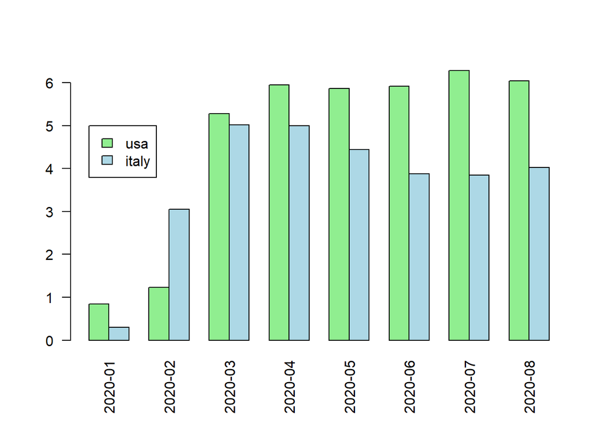

```r
barplot(log10(as.matrix(t(usa_italy[,2:3]))),
        beside = T,
        names=usa_monthly_average$newdate,
        las=2, col=c("lightgreen","lightblue"))
legend(1,5,c("usa","italy"),fill=c("lightgreen","lightblue"))
```

## Boxplot

Barplots are helpful but they are missing information about the variation in the data. In order to capture the daily variation, we will look at each daily value but group them by month.

To create a boxplot go back to the original dataset and plot `cases ~ newdate` after filtering for just **US** values. The `~` is read, *in response to* or *grouped by*. We will use this notation quite a bit later on in class for grouping data based on categories.

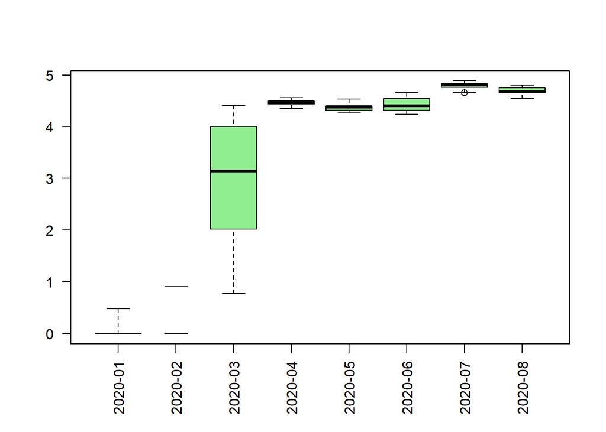

```r
#boxplot(log10(cases) ~ newdate, data=usa, ann=F,las=2,col="lightgreen")

boxplot(log10(cases) ~ newdate,
        ann=F,las=2,col="lightgreen",
        data=covid %>%
          filter(type=="confirmed") %>%
          filter(country=="US"))
```

Boxplot has a nice feature where you can create a second boxplot and use the `add=T` option to draw the new boxplot on the same graph. Due to devise constaints in an Rmarkdown, all the plotting code should be in the same chunk. So re-rerun the code above followed by another `boxplot` command for **italy** with the `add=T` option. Remember: - take the `log10()` of the cases - choose different colors for both datasets.

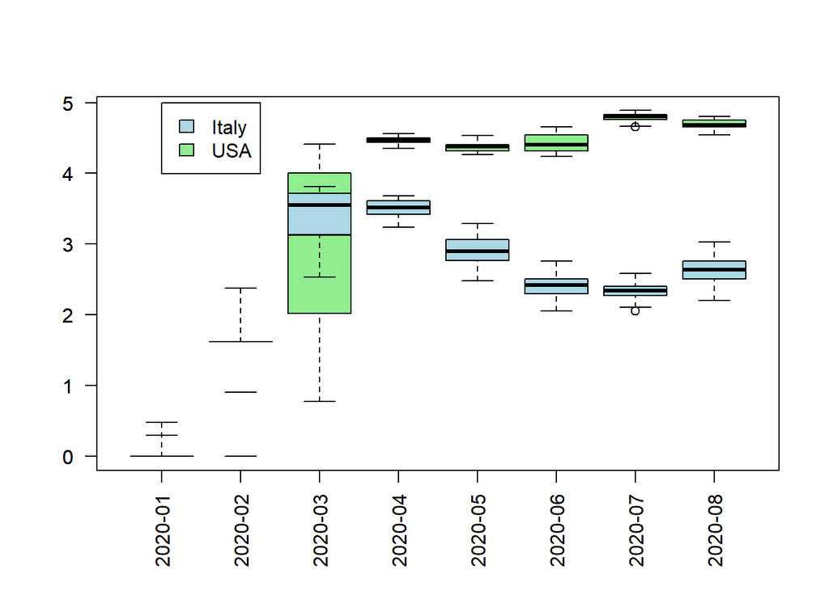

```r
boxplot(log10(cases) ~ newdate,
          data=covid %>%
          filter(type=="confirmed") %>%
          filter(country=="US"),
        ann=F,las=2,col="lightgreen")

boxplot(log10(cases) ~ newdate, names=NA,las=2,
        data=covid %>%
          filter(type=="confirmed") %>%
          filter(country=="Italy"),
        add = T,ann=F,
        col="lightblue")
legend(1,5,c("Italy","USA"),fill=c("lightblue","lightgreen"))
```